# Improve network plots

M. Fisher

1/16/2022

This script requires the following packages.

```r
if(!require("tidyverse")) {install.packages("tidyverse")}
if(!require("ggplot2")) {install.packages("ggplot2")}
if(!require("igraph")) {install.packages("igraph")}
if(!require("RColorBrewer")) {install.packages("RColorBrewer")}
if(!require("stringr")) {install.packages("stringr")}
```

And calls the following functions:

```r
source(here::here('R/color_network_nodes.R'))
source(here::here('R/plot_network.R'))
#source(here::here('R/plot_simple_network.R'))
source(here::here('R/plot_network_bulk_comparable.R')) # note this script is flexible whether we want to plot vessel-level or aggregate (bulk) networks. simply change the file_suffix. similarly, it is flexible whether we want to plot port group or state networks, simply change how 'port_group' is defined based on unique(V(g)$p)
```

# User Inputs

Select your directories.

```r
## location of igraph objects
indir_ports = 'data/networks/participation_vessel_ports'

## output directory for network viz
pngdir_ports = 'data/networks/participation_vessel_ports/plots/comparable'
```

Identify the crab years and port groups that you would like to produce networks for.

```r
## (crab) years
years <- seq(2019,2020)
# years <- 2008 # testing script, 1/6
# years <- 2018 # testing script, 1/8
# years <- 2014 # testing script, 1/27

## port groups
myports <- c("Puget Sound","North WA Coast","WA Coast","Other Coastal Washington","Astoria","Tillamook","Columbia River","Newport","Coos Bay","Brookings","Crescent City","Eureka","Morro Bay","Fort Bragg","Bodega Bay","San Francisco","San Diego","Monterey","Santa Barbara","Los Angeles","Unknown Ports" )
#myports <- c("BDG") # testing script, 1/6
#myports <- c("Columbia River") # testing script for single node networks, 1/7
# myports <- c("Monterey") # testing script, 1/8
# myports <- c("Bodega Bay") # testing script, 1/27/21
```

Do you want to plot using the Fruchterman & Reingold layout [“fr”], a circular layout [“c”], or both [“both”]?

```r
my_layout <- "both"
```

# 1: Read in data

## 1) Vessel-level networks summarized by port group

B)(ii) and C)(i) A minimum annual total fisheries revenue cutoff for each vessel of $5,000, and a minimum annual individual fisheries revenue cutoff for each vessel of $500. Edge type is connectivity.

```r
total_rev_cutoff <- 5000
indiv_rev_cutoff <- 500
edgetype <- "connectivity"
## To avoid inclusion of rare or minimal fishing activity, a given fishery must contribute to at least contr_cutoff% of a port's seasonal revenue to be included in the network data. This cutoff value can be increased if more stringent fishery inclusion criteria are preferred, and decreased (i.e. for summaries over shorter temporal / smaller spatial scales).
contr_cutoff <- 0.1
```

Read the igraph objects into a list. This for loop will also apply the functions to recolor and rename vertices

```r
#palette(brewer.pal(n = 10, name = "Set3"))
#pal3 <- brewer.pal(n = 10, name = "Set3")

graphs_list <- list()
graph_names <- c()
i=1
for(iopac in myports){
  for(y in years){
  #y=2013 # testing script for single node networks, 1/7
  # y=2014 # testing script for single node networks, 1/27
    if(file.exists(here::here(indir_ports,paste0("igraph_", iopac, "_", y, "_totalrev", total_rev_cutoff,"_indivrev", indiv_rev_cutoff,"_", edgetype,"_rmCrab.rds")))){
      tmpgraph <- readRDS(here::here(indir_ports,paste0("igraph_", iopac, "_", y, "_totalrev", total_rev_cutoff,"_indivrev", indiv_rev_cutoff,"_", edgetype,"_rmCrab.rds")))
      V(tmpgraph)$p <- iopac
      V(tmpgraph)$year <- y
      V(tmpgraph)$colors <- vertex_color(tmpgraph)
      graphs_list[[i]] <- tmpgraph
      graph_names[i] <- paste0(iopac,"_",y)
      i = i + 1
      } else{ y = y +1 }
  }
}
names(graphs_list) <- graph_names
```

# 2: Plot in circular layout

```r
glist <- graphs_list
names(glist)
```

```
##  [1] "Puget Sound_2019"    "Puget Sound_2020"    "North WA Coast_2019"
##  [4] "North WA Coast_2020" "WA Coast_2019"       "WA Coast_2020"
##  [7] "Astoria_2019"        "Astoria_2020"        "Tillamook_2019"
## [10] "Tillamook_2020"      "Columbia River_2019" "Columbia River_2020"
## [13] "Newport_2019"        "Newport_2020"        "Coos Bay_2019"
## [16] "Coos Bay_2020"       "Brookings_2019"      "Brookings_2020"
## [19] "Crescent City_2019"  "Crescent City_2020"  "Eureka_2019"
## [22] "Eureka_2020"         "Morro Bay_2019"      "Morro Bay_2020"
## [25] "Fort Bragg_2019"     "Fort Bragg_2020"     "Bodega Bay_2019"
## [28] "Bodega Bay_2020"     "San Francisco_2019"  "San Francisco_2020"
## [31] "San Diego_2019"      "San Diego_2020"      "Monterey_2019"
## [34] "Monterey_2020"       "Santa Barbara_2019"  "Santa Barbara_2020"
## [37] "Los Angeles_2019"    "Los Angeles_2020"    "Unknown Ports_2019"
## [40] "Unknown Ports_2020"
```

Prepare to graph the two networks with vertexes in the same locations.

```r
######## set up - functions ########
# get the vertex IDs for a graph
get_vid <- function(igraph_obj){
  vertex_attr(igraph_obj)[[1]]
}

# add () to vessel counts, and remove 0 vessel counts, for plotting
add_vessel_labels <- function(igraph_obj){
  label_vec <- c()
  for(i in seq(1,length(V(igraph_obj)$name))){
    if(V(igraph_obj)$vessels[i] != 0){
      label_vec[i] <- paste0(" (", V(igraph_obj)$vessels[i], ")")
    } else{
      label_vec[i] <- ""
    }
  }
  return(label_vec)
}
###################################


# get all the unique node IDs from the list of graphs you want to compare
unique_node_ids <- unique(unlist(lapply(glist,get_vid)))

# build a matrix to see which graphs have which nodes
node_mat <- matrix(nrow=length(unique_node_ids), ncol=length(glist), dimnames=list(c(unique_node_ids),
                                                                                   c(seq(1,length(glist)))))
for(i in seq(1,dim(node_mat)[2])){     # for each graph
  for(j in seq(1,dim(node_mat)[1])){   # for each node
    tmp_g <- glist[[i]]
    tmp_node <- unique_node_ids[j]
    if(tmp_node %in% get_vid(tmp_g)){
      node_mat[j,i] <- 1
    } else{
      node_mat[j,i] <- 0
    }
  }
}

# if any graphs are missing a node, add it in as a blank
new_glist = list()
for(i in seq(1,dim(node_mat)[2])){
  tmp_g <- glist[[i]]
  if(any(node_mat[,i] == 0)){
    # identify the missing nodes
    missing_nodes <- c(unique_node_ids[which(!(unique_node_ids %in% get_vid(tmp_g)))])
    for(j in seq(1,length(missing_nodes))){
      tmp_node <- missing_nodes[j]

      # get attributes from a graph that does have that node
      ref_g <- glist[[which(node_mat[tmp_node,] == 1)[[1]]]]
      ref_attr <- vertex_attr(ref_g, index=which(V(ref_g)$name == tmp_node))

      # reset graph-specific attributes
      # -- to zero
      ref_attr$size         <- 0
      ref_attr$percent_size <- 0
      ref_attr$importance   <- 0
      ref_attr$vessels      <- 0
      # -- to reflect new graph
      ref_attr$p            <- unique(V(tmp_g)$p)
      ref_attr$year         <- unique(V(tmp_g)$year)
      ref_attr$fleet        <- unique(V(tmp_g)$fleet)

      # add new node to graph
      if(j==1){
        new_tmp_g <- add_vertices(tmp_g, nv=1, attr=ref_attr)
      } else{
        new_tmp_g <- add_vertices(new_tmp_g, nv=1, attr=ref_attr)
      }

    } # end for(j)
    new_glist[[i]] <- new_tmp_g
    message("added ", length(missing_nodes), " empty vertices to graph ", i)

  } else{
    new_glist[[i]] <- tmp_g}  # end if(any == 0)
} # for(i)
```

```
## added 9 empty vertices to graph 1
```

```
## added 8 empty vertices to graph 2
```

```
## added 11 empty vertices to graph 3
```

```
## added 10 empty vertices to graph 4
```

```
## added 11 empty vertices to graph 5
```

```
## added 9 empty vertices to graph 6
```

```
## added 12 empty vertices to graph 7
```

```
## added 11 empty vertices to graph 8
```

```
## added 11 empty vertices to graph 9
```

```
## added 11 empty vertices to graph 10
```

```
## added 16 empty vertices to graph 11
```

```
## added 16 empty vertices to graph 12
```

```
## added 10 empty vertices to graph 13
```

```
## added 9 empty vertices to graph 14
```

```
## added 9 empty vertices to graph 15
```

```
## added 8 empty vertices to graph 16
```

```
## added 11 empty vertices to graph 17
```

```
## added 11 empty vertices to graph 18
```

```
## added 12 empty vertices to graph 19
```

```
## added 11 empty vertices to graph 20
```

```
## added 10 empty vertices to graph 21
```

```
## added 10 empty vertices to graph 22
```

```
## added 9 empty vertices to graph 23
```

```
## added 10 empty vertices to graph 24
```

```
## added 11 empty vertices to graph 25
```

```
## added 11 empty vertices to graph 26
```

```
## added 10 empty vertices to graph 27
```

```
## added 11 empty vertices to graph 28
```

```
## added 8 empty vertices to graph 29
```

```
## added 10 empty vertices to graph 30
```

```
## added 10 empty vertices to graph 31
```

```
## added 8 empty vertices to graph 32
```

```
## added 11 empty vertices to graph 33
```

```
## added 9 empty vertices to graph 34
```

```
## added 10 empty vertices to graph 35
```

```
## added 7 empty vertices to graph 36
```

```
## added 6 empty vertices to graph 37
```

```
## added 7 empty vertices to graph 38
```

```
## added 11 empty vertices to graph 39
```

```
## added 9 empty vertices to graph 40
```

Plot the first graph

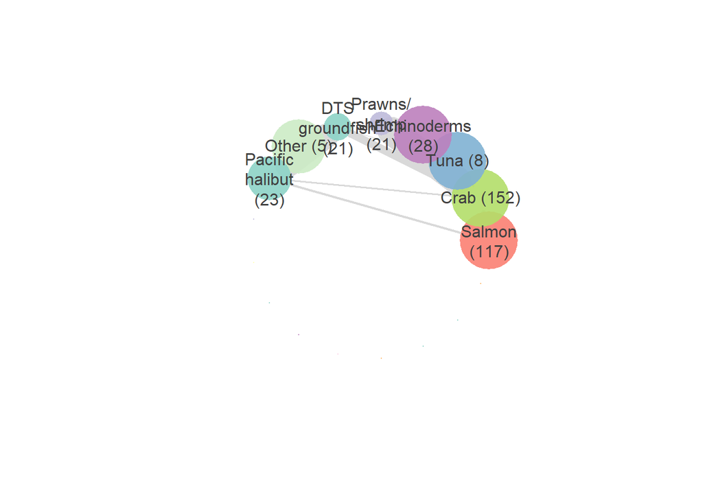

```r
g <- new_glist[[1]]
# get port group / year info from graph object
port_group <- unique(V(g)$p)
y <- unique(V(g)$year)
# prepare the layout with the `layout_in_circle` function, which allows you to specify vertex order for plot
new_order <- match(unique_node_ids,V(g)$name)
l <-layout_in_circle(g, order=new_order)
# remove labels for empty nodes
V(g)$common_name[which(V(g)$vessels == 0)] <- ""
V(g)$vessel_label <- add_vessel_labels(g)


## plotting function if there are 1+ edges in the graph (there are)
plot(g, vertex.size = V(g)$importance/(max(V(g)$importance)*0.02),
     layout = l, #where to put the nodes on the plot
     edge.width = sqrt(E(g)$weight)/(0.037*max(sqrt(E(g)$weight))),
     edge.curved = F,
     axes = F,
     edge.color = brewer.pal(n = 11, name = "Set3")[9],
     # vertex.label = remove_empty_labels(g),
     vertex.label = str_wrap(paste0(V(g)$common_name, V(g)$vessel_label),
                             width = 10), # JS updated 01-29-2021
     vertex.color =adjustcolor(V(g)$colors, alpha.f=0.90),
     vertex.label.family = 'sans',
     # vertex.label.color = V(tmp_g)$colors, # to have same color as vertices
     vertex.label.color = "grey25",
     vertex.label.cex= 1, # changed from 1.2, JS 01-29-21
     vertex.frame.color=NA
     # vertex.label.dist = c(-9,-8,-9,-10),               # these can be adjusted manually to make it look nicer, which is super annoying
     # vertex.label.degree = c(pi^(0.9),pi/5,pi/5,pi*1.1) # these can be adjusted manually to make it look nicer, which is super annoying
)
```

Do the same thing, but save into png

```r
png(here('data','networks','test_igraph1.png'),bg="transparent")
plot(g, vertex.size = V(g)$importance/(max(V(g)$importance)*0.02),
     layout = l, #where to put the nodes on the plot
     edge.width = sqrt(E(g)$weight)/(0.037*max(sqrt(E(g)$weight))),
     edge.curved = F,
     axes = F,
     edge.color = brewer.pal(n = 11, name = "Set3")[9],
     # vertex.label = remove_empty_labels(g),
     vertex.label = str_wrap(paste0(V(g)$common_name, V(g)$vessel_label),
                             width = 10), # JS updated 01-29-2021
     vertex.color =adjustcolor(V(g)$colors, alpha.f=0.90),
     vertex.label.family = 'sans',
     # vertex.label.color = V(tmp_g)$colors, # to have same color as vertices
     vertex.label.color = "grey25",
     vertex.label.cex= 1.6, # changed from 1.2, JS 01-29-21
     vertex.frame.color=NA
     # vertex.label.dist = c(-9,-8,-9,-10),               # these can be adjusted manually to make it look nicer, which is super annoying
     # vertex.label.degree = c(pi^(0.9),pi/5,pi/5,pi*1.1) # these can be adjusted manually to make it look nicer, which is super annoying
)
dev.off()
```

### radian.rescale

From [kjhealy’s gist](https://gist.github.com/kjhealy/834774):

```
  The igraph docs say that vertex.label.degree controls the position of the labels with respect to the vertices. It's interpreted as a radian, like this:  Value is : Label appears ... the node
  -pi/2: above
  0: to the right of
  pi/2: below
  pi: to the left of

  We can generalize this. vertex.label.degree can take a vector as well as a scalar for its argument. So we write a function to  calculate the right position for a label based on its vertex's location on the circle. Get the labels aligned consistently around the edge of the circle for any n of nodes.  This code borrows bits of ggplot2's polar_coord function.
   start = offset from 12 o'clock in radians
   direction = 1 for clockwise; -1 for anti-clockwise.
```

```r
radian.rescale <- function(x, start=0, direction=1) {
  c.rotate <- function(x) (x + start) %% (2 * pi) * direction
  c.rotate(scales::rescale(x, c(0, 2 * pi), range(x)))
}
```

I’ve done two things the in new plot: applied radian.rescale to label the nodes with common name, and put the vessel counts at the center of the node.

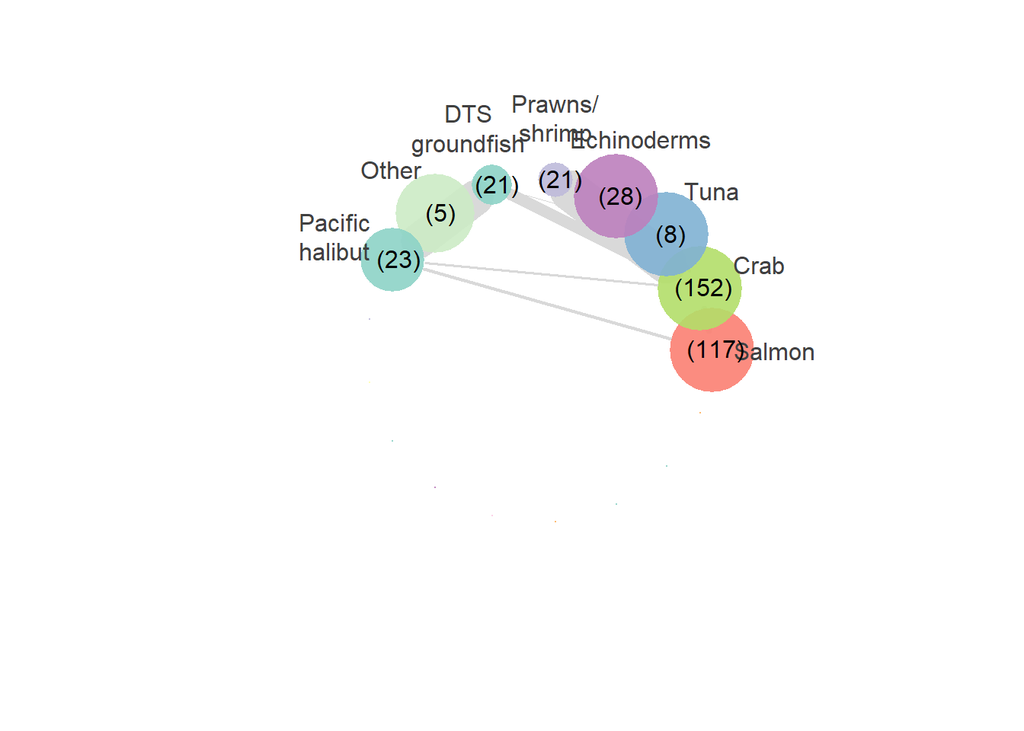

```r
lab.locs <- radian.rescale(x=1:vcount(g), direction=-1, start=0)

# png(here('data','networks','test_igraph1_rescale.png'),bg="transparent")
plot(g, vertex.size = V(g)$importance/(max(V(g)$importance)*0.02),
     layout = l, #where to put the nodes on the plot
     edge.width = sqrt(E(g)$weight)/(0.037*max(sqrt(E(g)$weight))),
     edge.curved = F,
     axes = F,
     edge.color = brewer.pal(n = 11, name = "Set3")[9],
     # vertex.label = remove_empty_labels(g),
     vertex.label = str_wrap(V(g)$common_name,
                             width = 6), # JS updated 01-29-2021   ## NEW- just the common name
     vertex.color =adjustcolor(V(g)$colors, alpha.f=0.90),
     vertex.label.family = 'sans',
     # vertex.label.color = V(tmp_g)$colors, # to have same color as vertices
     vertex.label.color = "grey25",
     vertex.label.cex= 1, # changed from 1.2, JS 01-29-21
     vertex.frame.color=NA,
     vertex.label.dist = 5,                         ## NEW- distance of label from node center
     vertex.label.degree=lab.locs                   ## NEW- rescaled label locations
     )
text(x=l[,1], y=l[,2], labels=V(g)$vessel_label)    ## NEW- put the vessel counts at the center of each node.
```

```r
# dev.off()
```

Two more things to fix:

- the top of the graph is a little crowded. I think that (1) Echinoderm needs to be split between two lines, and (2) I can adjust the “start” argument of the rescale function to spread out the labels at the top of the graph (`lab.locs`).
- the name labels need to be slightly farther from the center of the node if the node is really large (`lab.dist`)

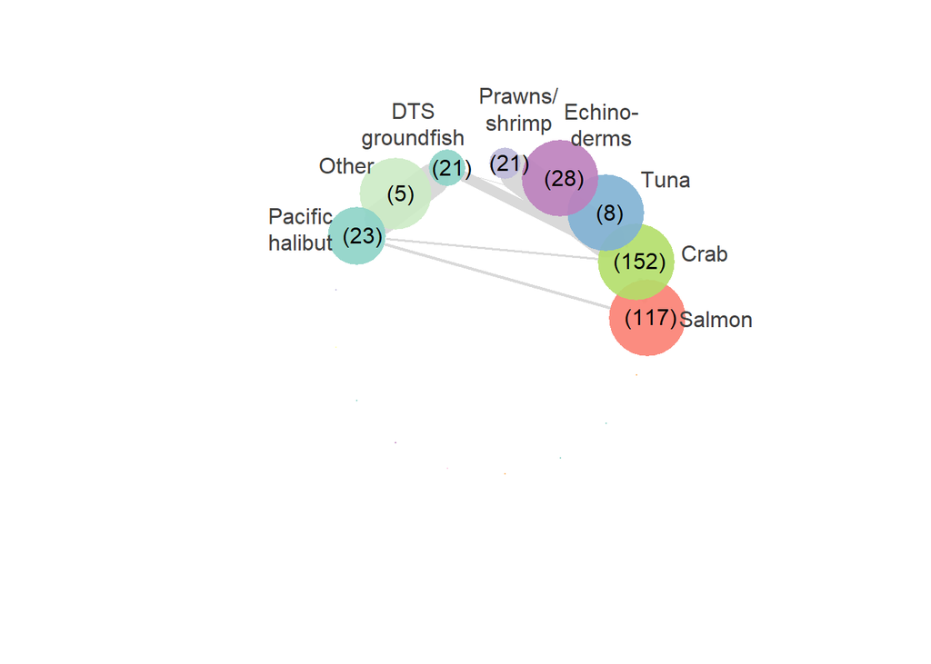

```r
V(g)$common_name <- ifelse(V(g)$common_name=="Echinoderms","Echino-\nderms",V(g)$common_name)


lab.locs <- ifelse((l[,1]==1 & l[,2]==0) | (l[,1]==0 & l[,2]==1), radian.rescale(x=1:vcount(g), direction=-1, start=0),
                   ifelse(l[,1] < 0, radian.rescale(x=1:vcount(g), direction=-1, start=0.25),
                   radian.rescale(x=1:vcount(g), direction=-1, start=-0.25)))

lab.dist <- ifelse(V(g)$importance/(max(V(g)$importance)*0.02) > 49, 6, 5)



# png(here('data','networks','test_igraph1_rescale_split.png'),bg="transparent")
plot(g, vertex.size = V(g)$importance/(max(V(g)$importance)*0.02),
     layout = l, #where to put the nodes on the plot
     edge.width = sqrt(E(g)$weight)/(0.037*max(sqrt(E(g)$weight))),
     edge.curved = F,
     axes = F,
     edge.color = brewer.pal(n = 11, name = "Set3")[9],
     # vertex.label = remove_empty_labels(g),
     vertex.label = str_wrap(V(g)$common_name,
                             width = 6), # JS updated 01-29-2021
     vertex.color =adjustcolor(V(g)$colors, alpha.f=0.90),
     vertex.label.family = 'sans',
     # vertex.label.color = V(tmp_g)$colors, # to have same color as vertices
     vertex.label.color = "grey25",
     vertex.label.cex= 1, # changed from 1.2, JS 01-29-21
     vertex.frame.color=NA,
     vertex.label.dist = lab.dist,
     vertex.label.degree=lab.locs
     )
text(x=l[,1], y=l[,2], labels=V(g)$vessel_label)
```

```r
# dev.off()
```

I think that looks better. Save it into a png.

```r
lab.locs <- ifelse((l[,1]==1 & l[,2]==0) | (l[,1]==0 & l[,2]==1), radian.rescale(x=1:vcount(g), direction=-1, start=0),
                   ifelse(l[,1] < 0, radian.rescale(x=1:vcount(g), direction=-1, start=0.25),
                   radian.rescale(x=1:vcount(g), direction=-1, start=-0.25)))

lab.dist <- ifelse(V(g)$importance/(max(V(g)$importance)*0.02) > 49, 6, 5)

png(here('data','networks','test_igraph1_rescale_split.png'),bg="transparent")
plot(g, vertex.size = V(g)$importance/(max(V(g)$importance)*0.02),
     layout = l, #where to put the nodes on the plot
     edge.width = sqrt(E(g)$weight)/(0.037*max(sqrt(E(g)$weight))),
     edge.curved = F,
     axes = F,
     edge.color = brewer.pal(n = 11, name = "Set3")[9],
     # vertex.label = remove_empty_labels(g),
     vertex.label = str_wrap(V(g)$common_name,
                             width = 6), # JS updated 01-29-2021
     vertex.color =adjustcolor(V(g)$colors, alpha.f=0.90),
     vertex.label.family = 'sans',
     # vertex.label.color = V(tmp_g)$colors, # to have same color as vertices
     vertex.label.color = "grey25",
     vertex.label.cex= 1.6, # changed from 1.2, JS 01-29-21
     vertex.frame.color=NA,
     vertex.label.dist = lab.dist,
     vertex.label.degree=lab.locs
     )
text(x=l[,1], y=l[,2], labels=V(g)$vessel_label)
dev.off()
```

### re-generate all graphs.

Let’s hope the new method works equally well across the different graphs.

```r
for(i in seq(1,length(new_glist))){
  g <- new_glist[[i]]
  # get port group / year info from graph object
  port_group <- unique(V(g)$p)
  y <- unique(V(g)$year)
  # prepare the layout with the `layout_in_circle` function, which allows you to specify vertex order for plot
  new_order <- match(unique_node_ids,V(g)$name)
  l <-layout_in_circle(g, order=new_order)
  # remove labels for empty nodes
  V(g)$common_name[which(V(g)$vessels == 0)] <- ""
  V(g)$vessel_label <- add_vessel_labels(g)


  V(g)$common_name <- ifelse(V(g)$common_name=="Echinoderms","Echino-\nderms",V(g)$common_name)
  lab.locs <- ifelse((l[,1]==1 & l[,2]==0) | (l[,1]==0 & l[,2]==1), radian.rescale(x=1:vcount(g), direction=-1, start=0),
                   ifelse(l[,1] < 0, radian.rescale(x=1:vcount(g), direction=-1, start=0.25),
                   radian.rescale(x=1:vcount(g), direction=-1, start=-0.25)))
  lab.dist <- ifelse(V(g)$importance/(max(V(g)$importance)*0.02) > 49, 6, 5)


  # plot & save to file
  png(here::here('data','networks', paste0(port_group,"_", y,"_circular_test.png")),bg="transparent")  # if this resolution isn't good enough, add: width = 2000, height = 1500,res=300
  if(vcount(g) == 1 | ecount(g) == 0){
    plot(g, vertex.size = V(g)$importance/(max(V(g)$importance)*0.02),
         layout = l, #where to put the nodes on the plot
         # edge.width = sqrt(E(g)$weight)/(0.037*max(sqrt(E(g)$weight))),
         edge.curved = F,
         axes = F,
         edge.color = brewer.pal(n = 11, name = "Set3")[9],
         vertex.label = str_wrap(paste0(V(g)$common_name),
                                 width = 6), # JS updated 01-29-2021
         vertex.color = adjustcolor(V(g)$colors, alpha.f=0.90),
         vertex.label.family = 'sans',
         # vertex.label.color = V(g)$colors, # to have same color as vertices
         vertex.label.color = "gray25",
         vertex.label.cex= 1.4, # changed from 1.2, JS 01-29-21
         vertex.frame.color=NA,
         vertex.label.dist = 5,
         vertex.label.degree=lab.locs
    )
    text(x=l[,1], y=l[,2], labels=V(g)$vessel_label)
    dev.off()
  } else{
    plot(g, vertex.size = V(g)$importance/(max(V(g)$importance)*0.02),
         layout = l, #where to put the nodes on the plot
         edge.width = sqrt(E(g)$weight)/(0.037*max(sqrt(E(g)$weight))),
         edge.curved = F,
         axes = F,
         edge.color = brewer.pal(n = 11, name = "Set3")[9],
         # vertex.label = remove_empty_labels(g),
         vertex.label = str_wrap(V(g)$common_name,
                                 width = 6), # JS updated 01-29-2021
         vertex.color =adjustcolor(V(g)$colors, alpha.f=0.90),
         vertex.label.family = 'sans',
         # vertex.label.color = V(tmp_g)$colors, # to have same color as vertices
         vertex.label.color = "grey25",
         vertex.label.cex= 1.4, # changed from 1.2, JS 01-29-21
         vertex.frame.color=NA,
         vertex.label.dist = 5,
         vertex.label.degree=lab.locs
    )
    text(x=l[,1], y=l[,2], labels=V(g)$vessel_label)
    dev.off()
  }
}
```

Nope, the labels get all weird. Trying the rescale function without getting fancy:

```r
for(i in seq(1,length(new_glist))){
  g <- new_glist[[i]]
  # get port group / year info from graph object
  port_group <- unique(V(g)$p)
  y <- unique(V(g)$year)
  # prepare the layout with the `layout_in_circle` function, which allows you to specify vertex order for plot
  new_order <- match(unique_node_ids,V(g)$name)
  l <-layout_in_circle(g, order=new_order)
  # remove labels for empty nodes
  V(g)$common_name[which(V(g)$vessels == 0)] <- ""
  V(g)$vessel_label <- add_vessel_labels(g)


  V(g)$common_name <- ifelse(V(g)$common_name=="Echinoderms","Echino-\nderms",V(g)$common_name)
  lab.locs <- radian.rescale(x=1:vcount(g), direction=-1, start=0)
  lab.dist <- ifelse(V(g)$importance/(max(V(g)$importance)*0.02) > 49, 6, 5)


  # plot & save to file
  png(here::here('data','networks', paste0(port_group,"_", y,"_circular_test2.png")),bg="transparent")  # if this resolution isn't good enough, add: width = 2000, height = 1500,res=300
 if(vcount(g) == 1 | ecount(g) == 0){
    plot(g, vertex.size = V(g)$importance/(max(V(g)$importance)*0.02),
         layout = l, #where to put the nodes on the plot
         # edge.width = sqrt(E(g)$weight)/(0.037*max(sqrt(E(g)$weight))),
         edge.curved = F,
         axes = F,
         edge.color = brewer.pal(n = 11, name = "Set3")[9],
         vertex.label = str_wrap(paste0(V(g)$common_name),
                                 width = 6), # JS updated 01-29-2021
         vertex.color = adjustcolor(V(g)$colors, alpha.f=0.90),
         vertex.label.family = 'sans',
         # vertex.label.color = V(g)$colors, # to have same color as vertices
         vertex.label.color = "gray25",
         vertex.label.cex= 1.4, # changed from 1.2, JS 01-29-21
         vertex.frame.color=NA,
         vertex.label.dist = 5,
         vertex.label.degree=lab.locs
    )
    text(x=l[,1], y=l[,2], labels=V(g)$vessel_label)
    dev.off()
  } else{
    plot(g, vertex.size = V(g)$importance/(max(V(g)$importance)*0.02),
         layout = l, #where to put the nodes on the plot
         edge.width = sqrt(E(g)$weight)/(0.037*max(sqrt(E(g)$weight))),
         edge.curved = F,
         axes = F,
         edge.color = brewer.pal(n = 11, name = "Set3")[9],
         # vertex.label = remove_empty_labels(g),
         vertex.label = str_wrap(V(g)$common_name,
                                 width = 6), # JS updated 01-29-2021
         vertex.color =adjustcolor(V(g)$colors, alpha.f=0.90),
         vertex.label.family = 'sans',
         # vertex.label.color = V(tmp_g)$colors, # to have same color as vertices
         vertex.label.color = "grey25",
         vertex.label.cex= 1.4, # changed from 1.2, JS 01-29-21
         vertex.frame.color=NA,
         vertex.label.dist = 5,
         vertex.label.degree=lab.locs
    )
    text(x=l[,1], y=l[,2], labels=V(g)$vessel_label)
    dev.off()
  }
}
```